# Alfredo_Heart Failure Prediction

## História do conjunto de dados:

Este conjunto de dados foi criado combinando diferentes conjuntos de dados já disponíveis independentemente, mas não combinados antes. Neste conjunto de dados, 5 conjuntos de dados cardíacos são combinados em 11 características comuns, o que o torna o maior conjunto de dados de doenças cardíacas disponível até agora para fins de pesquisa. Os cinco conjuntos de dados usados para sua curadoria são:

Cleveland: 303 observações Húngaro: 294 observações Suíça: 123 observações Long Beach VA: 200 observações Conjunto de dados Stalog (coração): 270 observações

### Objectivo e contexto:

Prever um ataque cardíaco (HeartDisease) é crucial no setor de saúde, e algoritmos de aprendizado de máquina podem ser bem-sucedidos em tais previsões. Este estudo tem como objetivo desenvolver um modelo de aprendizado de máquina para prever o risco de um ataque cardíaco usando os recursos em seu conjunto de dados.

Use o conunto de dados fornecido em coracao.csv e faca a predição de eventual ataque cardíaco ou não Usando a Regressão Logistica .

### Variavel Descrição

Age: Idade do paciente em anos

- Sex: 1=masculino; 0 = femenino
- ChestPainType: Tipo da dor de peito
- RestingBP: Pressao arterial em discanso
- Cholesterol: Colesterol
- FastingBS: Nivel de açúcar no sangue em jejum
- RestingECG: Resultados eletrocardiográficos em repouso.
- MaxHR: Frequência cardíaca máxima alcançada. A frequência cardíaca máxima é 220 menos sua idade.
- ExerciseAngina: Angina induzida por exercício (1 sim). Angina é um tipo de dor no peito causada pela redução do fluxo sanguíneo para o coração. Angina é um sintoma de doença arterial coronária.
- Oldpeak: Depressão induzida pelo exercício em relação ao repouso.
- ST_Slope: Inclinação do segmento ST de pico do exercício.
- HeartDisease: Estado angiográfico da doença sem doença = 0 e doença = 1

### Bibliotecas para Regressão Logística

```python
# To filter the warnings
import warnings

warnings.filterwarnings("ignore")

# Libraries to help with reading and manipulating data
import pandas as pd
import numpy as np

# libraries to help with data visualization
import matplotlib.pyplot as plt
import seaborn as sns

# Library to split data
from sklearn.model_selection import train_test_split


# To build linear model for statistical analysis and prediction
import statsmodels.stats.api as sms
from statsmodels.stats.outliers_influence import variance_inflation_factor
import statsmodels.api as sm
from statsmodels.tools.tools import add_constant

# To get diferent metric scores
from sklearn import metrics
from sklearn.metrics import accuracy_score, roc_curve, confusion_matrix, roc_auc_score


# this will help in making the Python code more structured automatically (good coding practice)
#%load_ext nb_black
```

**Carregando e Explorando os Dados**

```python
data = pd.read_csv(r"C:\Users\j040m\Music\CURSO\Modulo 2- Modelos lineares generalizados\coracao\coracao.csv")
```

**Visualizando as primeiras e últimas 5 linhas do conjunto de dados**

```python
data.head()
```

|  | Age | Sex | ChestPainType | RestingBP | Cholesterol | FastingBS | RestingECG | MaxHR | ExerciseAngina | Oldpeak | ST_Slope | HeartDisease |
| --- | --- | --- | --- | --- | --- | --- | --- | --- | --- | --- | --- | --- |
| 0 | 40 | M | ATA | 140 | 289 | 0 | Normal | 172 | N | 0.0 | Up | 0 |
| 1 | 49 | F | NAP | 160 | 180 | 0 | Normal | 156 | N | 1.0 | Flat | 1 |
| 2 | 37 | M | ATA | 130 | 283 | 0 | ST | 98 | N | 0.0 | Up | 0 |
| 3 | 48 | F | ASY | 138 | 214 | 0 | Normal | 108 | Y | 1.5 | Flat | 1 |
| 4 | 54 | M | NAP | 150 | 195 | 0 | Normal | 122 | N | 0.0 | Up | 0 |

```python
data.tail()
```

|  | Age | Sex | ChestPainType | RestingBP | Cholesterol | FastingBS | RestingECG | MaxHR | ExerciseAngina | Oldpeak | ST_Slope | HeartDisease |
| --- | --- | --- | --- | --- | --- | --- | --- | --- | --- | --- | --- | --- |
| 913 | 45 | M | TA | 110 | 264 | 0 | Normal | 132 | N | 1.2 | Flat | 1 |
| 914 | 68 | M | ASY | 144 | 193 | 1 | Normal | 141 | N | 3.4 | Flat | 1 |
| 915 | 57 | M | ASY | 130 | 131 | 0 | Normal | 115 | Y | 1.2 | Flat | 1 |
| 916 | 57 | F | ATA | 130 | 236 | 0 | LVH | 174 | N | 0.0 | Flat | 1 |
| 917 | 38 | M | NAP | 138 | 175 | 0 | Normal | 173 | N | 0.0 | Up | 0 |

**Entendendo a forma do conjunto de dados**

```python
# Verifica o shape dos dados
print(f'Shape dos dados: {data.shape}\n')

print(f'Esta base de dados tem {data.shape[0]} observações e {data.shape[1]} variaveis.')
```

```
Shape dos dados: (918, 12)

Esta base de dados tem 918 observações e 12 variaveis.
```

**Verificando os valores nulose e duplicados nos dados**

```python
data.isnull().values.any()
```

```
False
```

```python
data.isnull().sum()
```

```
Age               0
Sex               0
ChestPainType     0
RestingBP         0
Cholesterol       0
FastingBS         0
RestingECG        0
MaxHR             0
ExerciseAngina    0
Oldpeak           0
ST_Slope          0
HeartDisease      0
dtype: int64
```

```python
data.duplicated().sum().any()
```

```
False
```

**Verificando os tipos de dados das variaveis para o conjunto de dados**

```python
data.info()
```

```
<class 'pandas.core.frame.DataFrame'>
RangeIndex: 918 entries, 0 to 917
Data columns (total 12 columns):
 #   Column          Non-Null Count  Dtype
---  ------          --------------  -----
 0   Age             918 non-null    int64
 1   Sex             918 non-null    object
 2   ChestPainType   918 non-null    object
 3   RestingBP       918 non-null    int64
 4   Cholesterol     918 non-null    int64
 5   FastingBS       918 non-null    int64
 6   RestingECG      918 non-null    object
 7   MaxHR           918 non-null    int64
 8   ExerciseAngina  918 non-null    object
 9   Oldpeak         918 non-null    float64
 10  ST_Slope        918 non-null    object
 11  HeartDisease    918 non-null    int64
dtypes: float64(1), int64(6), object(5)
memory usage: 86.2+ KB
```

- Há 7 variaveis numéricas(6 int e 1 float) nos dados e 5 de tipo de objeto.

**verificando o resumo estatístico dos dados.**

```python
data.describe().T
```

|  | count | mean | std | min | 25% | 50% | 75% | max |
| --- | --- | --- | --- | --- | --- | --- | --- | --- |
| Age | 918.0 | 53.510893 | 9.432617 | 28.0 | 47.00 | 54.0 | 60.0 | 77.0 |
| RestingBP | 918.0 | 132.396514 | 18.514154 | 0.0 | 120.00 | 130.0 | 140.0 | 200.0 |
| Cholesterol | 918.0 | 198.799564 | 109.384145 | 0.0 | 173.25 | 223.0 | 267.0 | 603.0 |
| FastingBS | 918.0 | 0.233115 | 0.423046 | 0.0 | 0.00 | 0.0 | 0.0 | 1.0 |
| MaxHR | 918.0 | 136.809368 | 25.460334 | 60.0 | 120.00 | 138.0 | 156.0 | 202.0 |
| Oldpeak | 918.0 | 0.887364 | 1.066570 | -2.6 | 0.00 | 0.6 | 1.5 | 6.2 |
| HeartDisease | 918.0 | 0.553377 | 0.497414 | 0.0 | 0.00 | 1.0 | 1.0 | 1.0 |

- As variaveis Cholesterol e RestingBP têm observações com valores 0, sendo que não é possivel. Estes erros de entrada de dados devem ser corrigidos.
- Se vai Substituir as entradas com 0 das variaveis citadas acima, pelo NaN (isso nos ajudará a lidar com os valores ausentes de forma elegante)
- Imputaremos valores ausentes (NaN) com a média/modo/mediana.
- Devemos também notar que o valor de colesterol máximo em um ser humana não passa da casa dos 200, logo pode-se observar que o valor máximo do mesmo chega a 600, então consideramos que existe uma discrepancia de valores(outlyier's)

```python
# Sumário das variaveis do tipo objeto
data.describe(include ="object")
```

|  | Sex | ChestPainType | RestingECG | ExerciseAngina | ST_Slope |
| --- | --- | --- | --- | --- | --- |
| count | 918 | 918 | 918 | 918 | 918 |
| unique | 2 | 4 | 3 | 2 | 3 |
| top | M | ASY | Normal | N | Flat |
| freq | 725 | 496 | 552 | 547 | 460 |

```python
# Verificando a quantidade de valores em todas as variavel
for i in data.columns:
    print(i,len(data[i].unique()))
```

```
Age 50
Sex 2
ChestPainType 4
RestingBP 67
Cholesterol 222
FastingBS 2
RestingECG 3
MaxHR 119
ExerciseAngina 2
Oldpeak 53
ST_Slope 3
HeartDisease 2
```

**Verificando a contagem e a porcentagem de níveis categóricos em cada variavel**

```python
# Making a list of all categorical variables
cat_cols =  ['Sex',	'ChestPainType','RestingECG','ExerciseAngina','ST_Slope']

# Printing the count of unique categorical levels in each column
for column in cat_cols:
    print(data[column].value_counts())
    print("-" * 50)
```

```
Sex
M    725
F    193
Name: count, dtype: int64
--------------------------------------------------
ChestPainType
ASY    496
NAP    203
ATA    173
TA      46
Name: count, dtype: int64
--------------------------------------------------
RestingECG
Normal    552
LVH       188
ST        178
Name: count, dtype: int64
--------------------------------------------------
ExerciseAngina
N    547
Y    371
Name: count, dtype: int64
--------------------------------------------------
ST_Slope
Flat    460
Up      395
Down     63
Name: count, dtype: int64
--------------------------------------------------
```

```python
# Printing the percentage of unique categorical levels in each column
for column in cat_cols:
    print(data[column].value_counts(normalize=True))
    print("-" * 50)
```

```
Sex
M   0.790
F   0.210
Name: proportion, dtype: float64
--------------------------------------------------
ChestPainType
ASY   0.540
NAP   0.221
ATA   0.188
TA    0.050
Name: proportion, dtype: float64
--------------------------------------------------
RestingECG
Normal   0.601
LVH      0.205
ST       0.194
Name: proportion, dtype: float64
--------------------------------------------------
ExerciseAngina
N   0.596
Y   0.404
Name: proportion, dtype: float64
--------------------------------------------------
ST_Slope
Flat   0.501
Up     0.430
Down   0.069
Name: proportion, dtype: float64
--------------------------------------------------
```

```python
# definindo as variaveis onde precisamos substituir 0 por NaN
cols = ["Cholesterol", "RestingBP"]
```

```python
# substituindo 0 por NaN
data[cols] = data[cols].replace(0, np.nan)
```

**Verificando os valores nulos nos dados novamente**

```python
data.isnull().values.any()
```

```
True
```

```python
data.isnull().sum()
```

```
Age                 0
Sex                 0
ChestPainType       0
RestingBP           1
Cholesterol       172
FastingBS           0
RestingECG          0
MaxHR               0
ExerciseAngina      0
Oldpeak             0
ST_Slope            0
HeartDisease        0
dtype: int64
```

# Análise exploratória de dados

## Análise de Dados Univariada

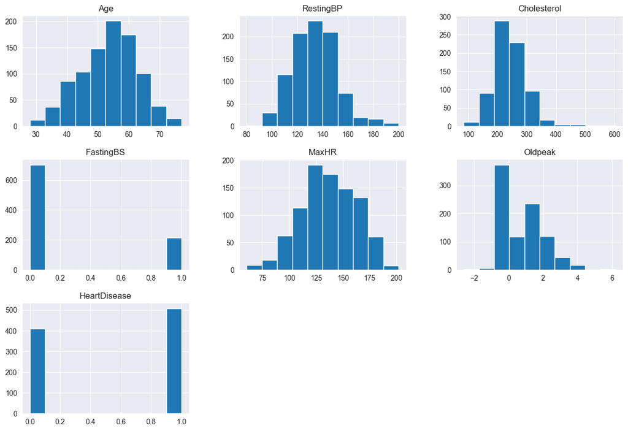

```python
sns.set_style("darkgrid")
data.hist(figsize=(15, 10))
plt.show()
```

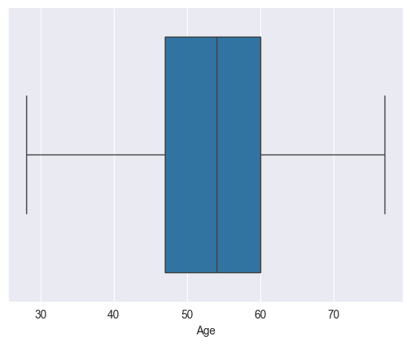

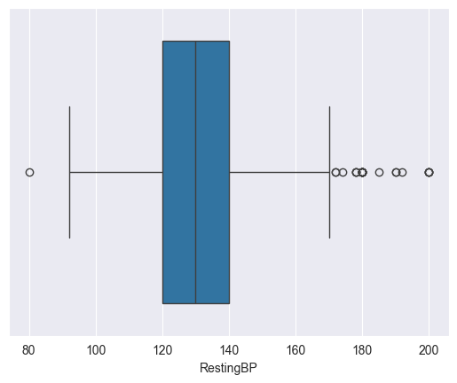

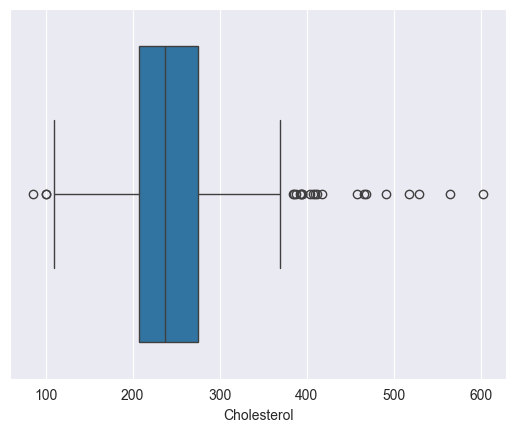

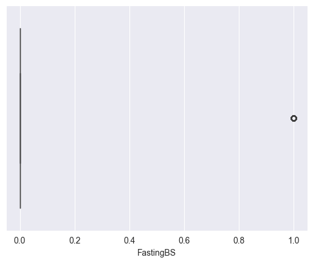

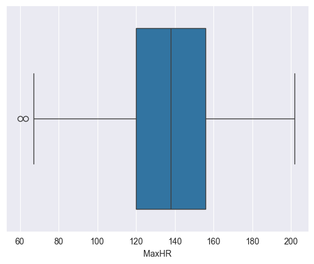

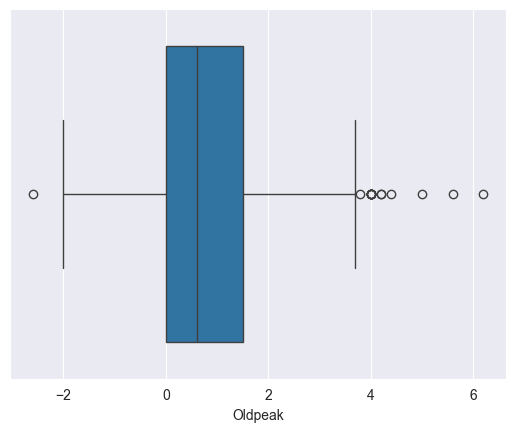

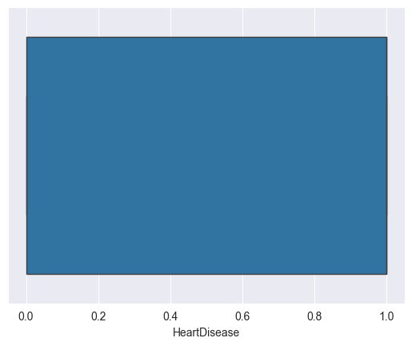

```python
for i in data.select_dtypes(include="number").columns:
    sns.boxplot(data=data,x=i)
    plt.show()
```

- Como podemos ver, existe uma consideravel descrepância na variável cholesterol, sendo assim uma das formas recomendadas de preencher as variaveis identificadas acima é por intermédio da mediana.

**Imputando os valores em falta nos dados**

```python
# Vamos imputar valores vamos verificar novamente os valores ausentes nos dadoses usando o valor médio
data[cols] = data[cols].fillna(data[cols].median())
```

**Verificando novamente os valores em falta nos dados**

```python
# vamos verificar novamente os valores ausentes nos dados
data.isna().sum()
```

```
Age               0
Sex               0
ChestPainType     0
RestingBP         0
Cholesterol       0
FastingBS         0
RestingECG        0
MaxHR             0
ExerciseAngina    0
Oldpeak           0
ST_Slope          0
HeartDisease      0
dtype: int64
```

- Imputamos todos os erros de entrada de dados com os valores médianos.

## Análise de Dados Bivariada

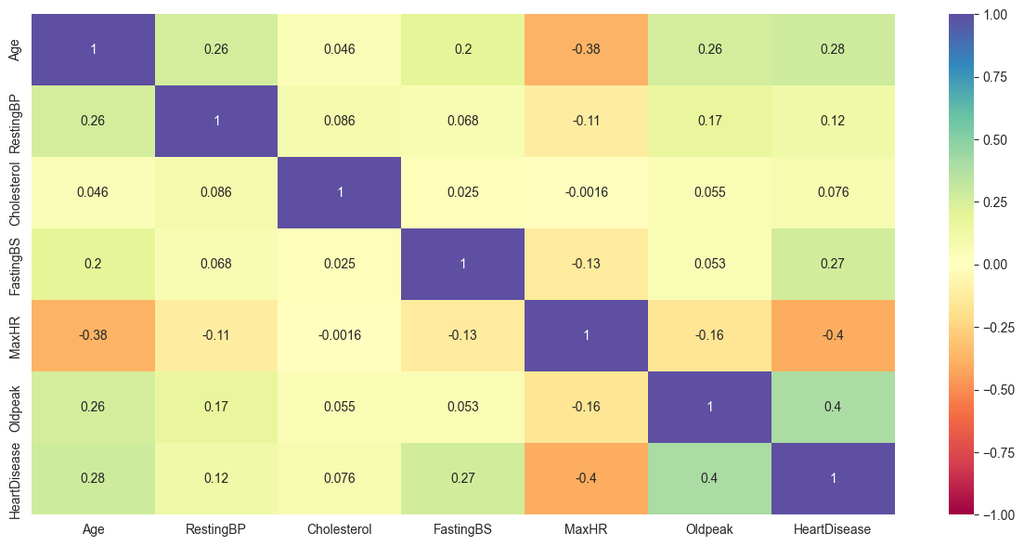

```python
plt.figure(figsize=(15,7))
sns.heatmap(data.select_dtypes(include="number").corr(),annot=True,cmap='Spectral',vmin=-1,vmax=1)
plt.show()
```

- Não é observado nenhum caso significativo de alta correlação entre as variáveis

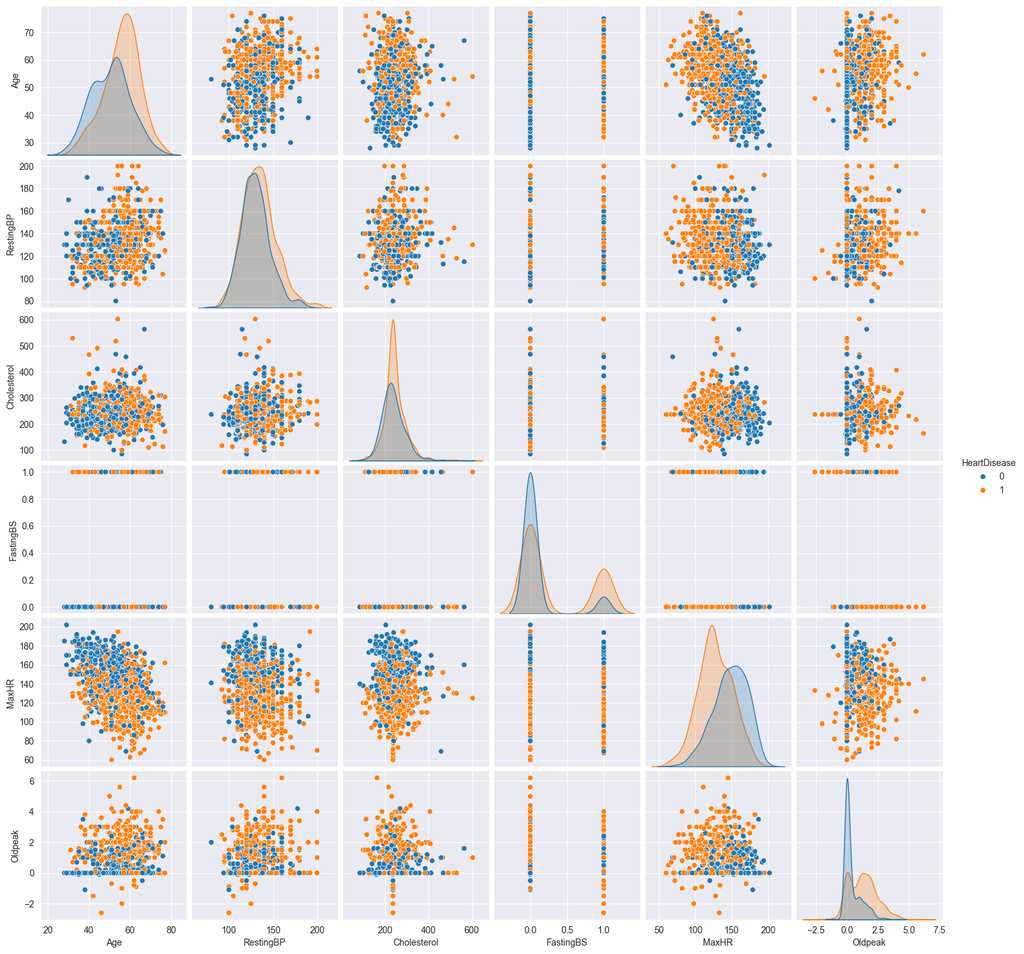

```python
sns.pairplot(data, hue="HeartDisease")
plt.show()
```

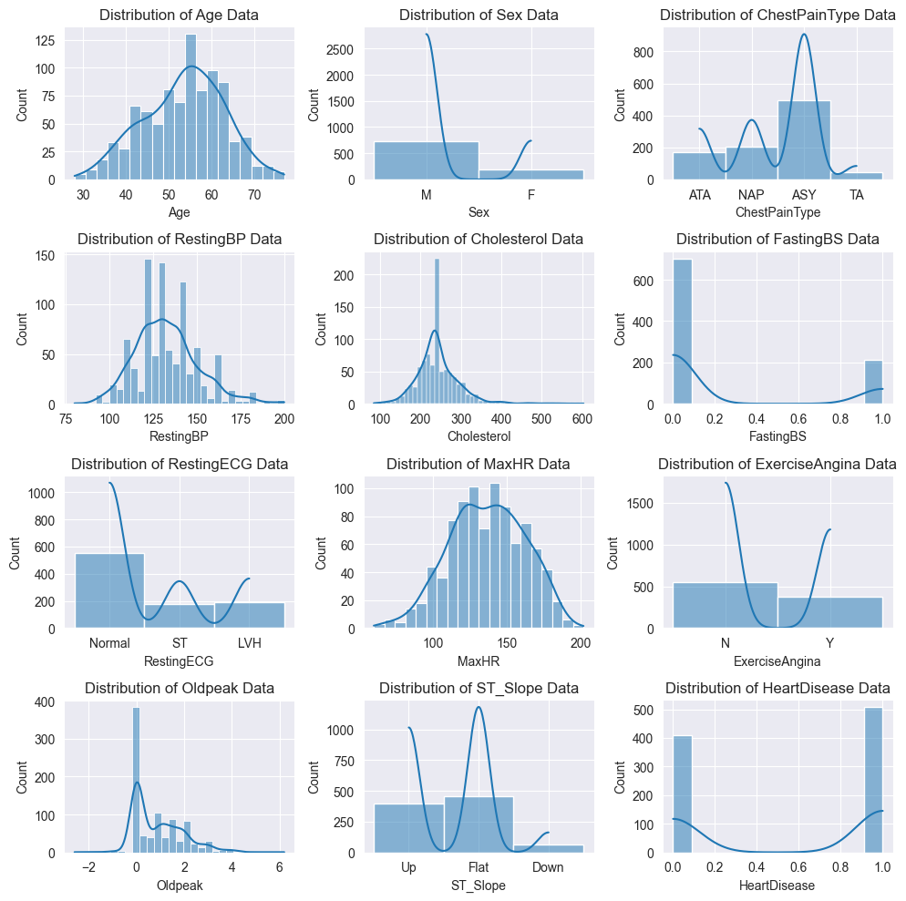

```python
plt.figure(figsize=(10,10))
for i,col in enumerate(data.columns,1):
    plt.subplot(4,3,i)
    plt.title(f"Distribution of {col} Data")
    sns.histplot(data[col],kde=True)
    plt.tight_layout()
    plt.plot()
```

### Observando as relações/distribuição da variável alvo

**Observações do Sex com relação ao HeartDisease**

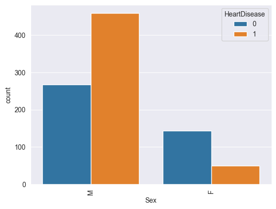

```python
sns.countplot(data=data,x='Sex',hue= 'HeartDisease')
plt.xticks(rotation=90)
plt.show()
```

**Observações do ST_Slope com relação ao HeartDisease**

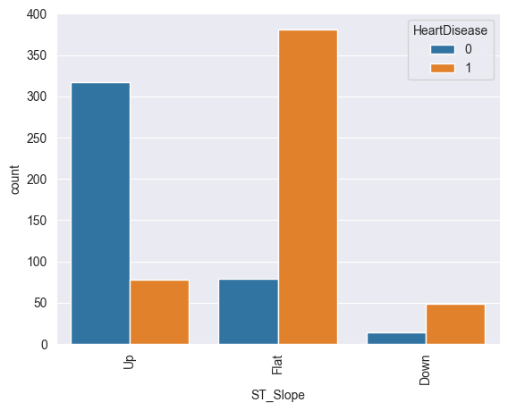

```python
sns.countplot(data=data,x='ST_Slope',hue= 'HeartDisease')
plt.xticks(rotation=90)
plt.show()
```

**Observações do ChestPainType com relação ao HeartDisease**

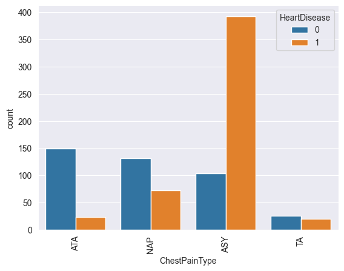

```python
sns.countplot(data=data,x='ChestPainType',hue= 'HeartDisease')
plt.xticks(rotation=90)
plt.show()
```

**Observações do FastingBS com relação ao HeartDisease**

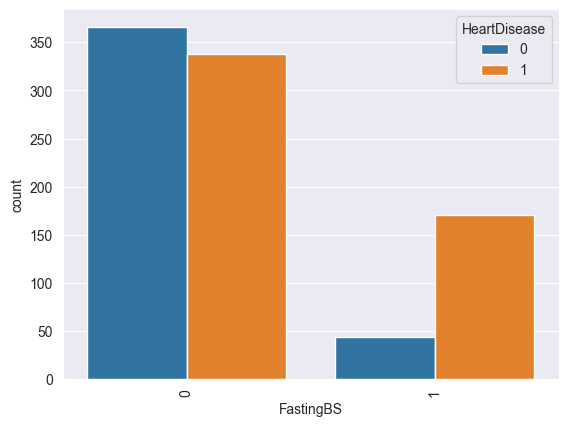

```python
sns.countplot(data=data,x='FastingBS',hue= 'HeartDisease')
plt.xticks(rotation=90)
plt.show()
```

**Observações do RestingECG com relação ao HeartDisease**

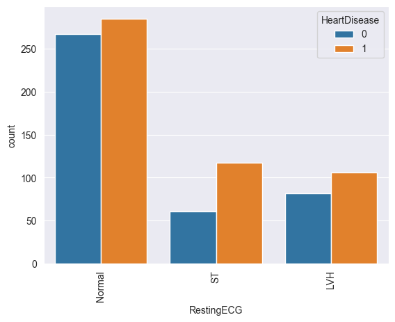

```python
sns.countplot(data=data,x='RestingECG',hue= 'HeartDisease')
plt.xticks(rotation=90)
plt.show()
```

**Observações do ExerciseAngina com relação ao HeartDisease**

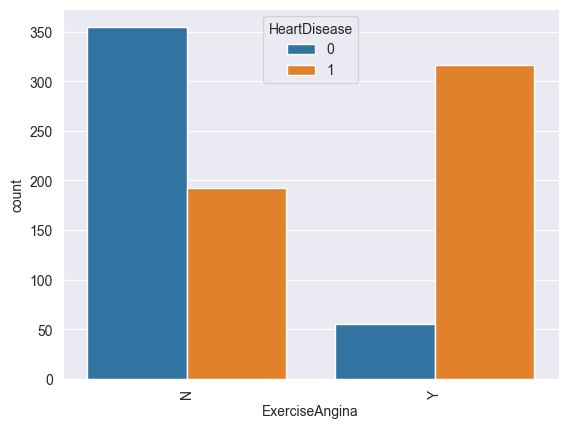

```python
sns.countplot(data=data,x='ExerciseAngina',hue= 'HeartDisease')
plt.xticks(rotation=90)
plt.show()
```

**Observações do RestingBP com relação ao HeartDisease**

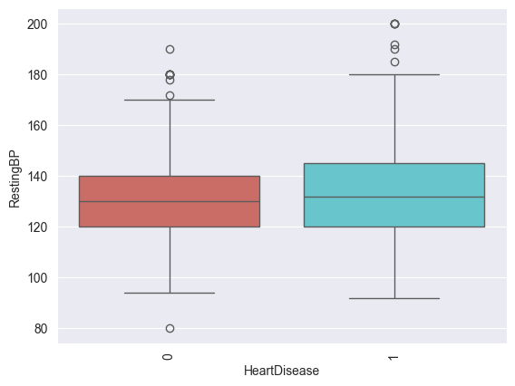

```python
sns.boxplot(data=data,x='HeartDisease',y='RestingBP',palette='hls')
plt.xticks(rotation=90)
plt.show();
```

- RestingBP tem sknews para a direita.
- A maioria dos indivíduos tem um RestingBP entre 120 e 140).
- A mediana do RestingBP é de cerca de 130, o que significa que metade dos indivíduos tem uma pressão arterial em repouso abaixo desse valor.

**Observações do MaxHR com relação ao HeartDisease**

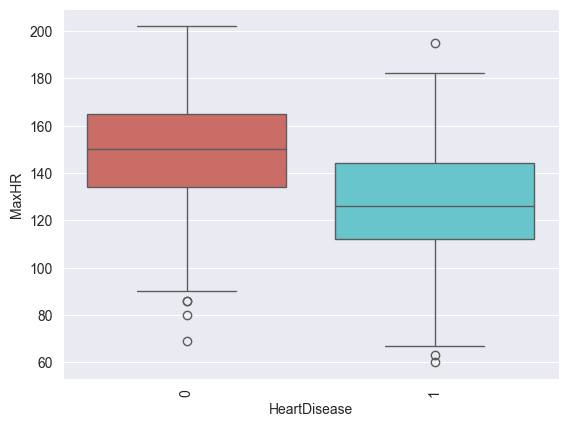

```python
sns.boxplot(data=data,x='HeartDisease',y='MaxHR',palette='hls')
plt.xticks(rotation=90)
plt.show();
```

A mediana de MaxHR é em torno de 140, o que significa que metade dos indivíduos tem um MaxHR abaixo desse valor e metade acima

Existem alguns indivíduos com valores de MaxHR significativamente mais baixos que indicam efeito com a doença.

**Observações do Cholesterol com relação ao HeartDisease**

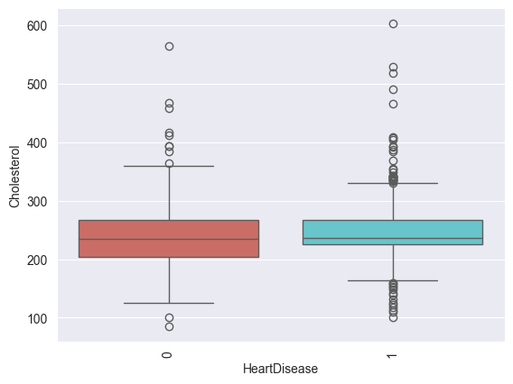

```python
sns.boxplot(data=data,x='HeartDisease',y='Cholesterol',palette='hls')
plt.xticks(rotation=90)
plt.show()
```

**Observações do Oldpeak com relação ao HeartDisease**

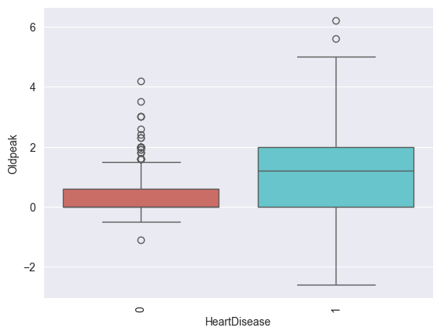

```python
sns.boxplot(data=data,x='HeartDisease',y='Oldpeak',palette='hls')
plt.xticks(rotation=90)
plt.show()
```

**Observações do Age com relação ao HeartDisease**

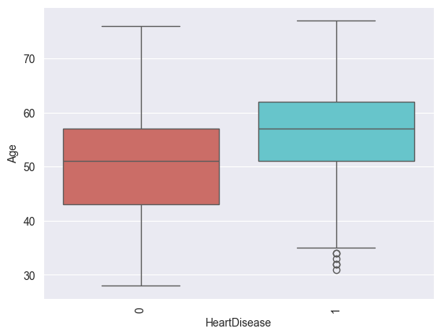

```python
sns.boxplot(data=data,x='HeartDisease',y='Age',palette='hls')
plt.xticks(rotation=90)
plt.show()
```

- A idade é um fator significativo na prevalência de doenças cardíacas, com indivíduos mais velhos sendo mais propensos a ter doenças cardíacas.
- Para aqueles com doenças cardíacas, a idade média é maior em comparação com aqueles sem elas.
- Embora as doenças cardíacas sejam mais comuns em faixas etárias mais velhas, elas também afetam um número notável de indivíduos mais jovens.

```python
data["HeartDisease"].value_counts()
```

```
HeartDisease
1    508
0    410
Name: count, dtype: int64
```

```python
data["HeartDisease"].value_counts(1)
```

```
HeartDisease
1    0.553377
0    0.446623
Name: proportion, dtype: float64
```

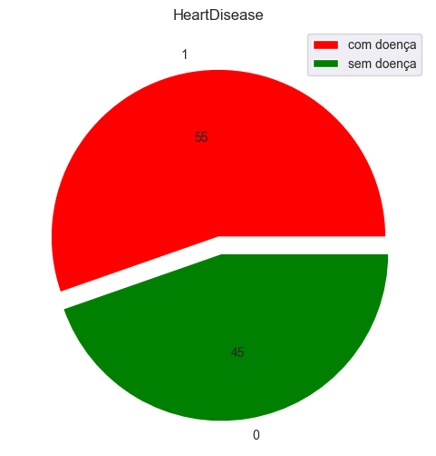

```python
labels=['1','0']
count= data['HeartDisease'].value_counts()
plt.figure(figsize=(6,6))
plt.pie(count,labels=labels,autopct='%.0f',explode=(0,.1), colors=['r','g'])
plt.legend( ['com doença','sem doença'],loc =1)

plt.title('HeartDisease')
plt.show()
```

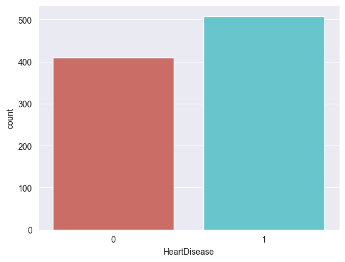

```python
# Distribuição de rótulos de classe
sns.countplot(x='HeartDisease',data=data, palette='hls')
plt.show()
```

- O número de observações em que a pessoa não é doente é de 410, o que representa 44% do total de dados disponíveis.
- O número de observações em que uma pessoa é doente é de 508, o que representa 55% do total de dados disponíveis.

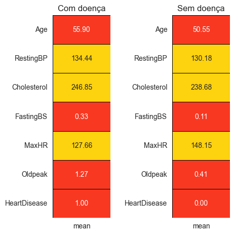

```python
yes = data[data['HeartDisease'] == 1].describe().T
no = data[data['HeartDisease'] == 0].describe().T
colors = ['#F93822','#FDD20E']

fig,ax = plt.subplots(nrows = 1,ncols = 2,figsize = (5,5))
plt.subplot(1,2,1)
sns.heatmap(yes[['mean']],annot = True,cmap = colors,linewidths = 0.4,linecolor = 'black',cbar = False,fmt = '.2f',)
plt.title('Com doença');

plt.subplot(1,2,2)
sns.heatmap(no[['mean']],annot = True,cmap = colors,linewidths = 0.4,linecolor = 'black',cbar = False,fmt = '.2f')
plt.title('Sem doença');

fig.tight_layout(pad = 2)
```

**Observações das variaveis categorias com HeartDisease positivo(1)**

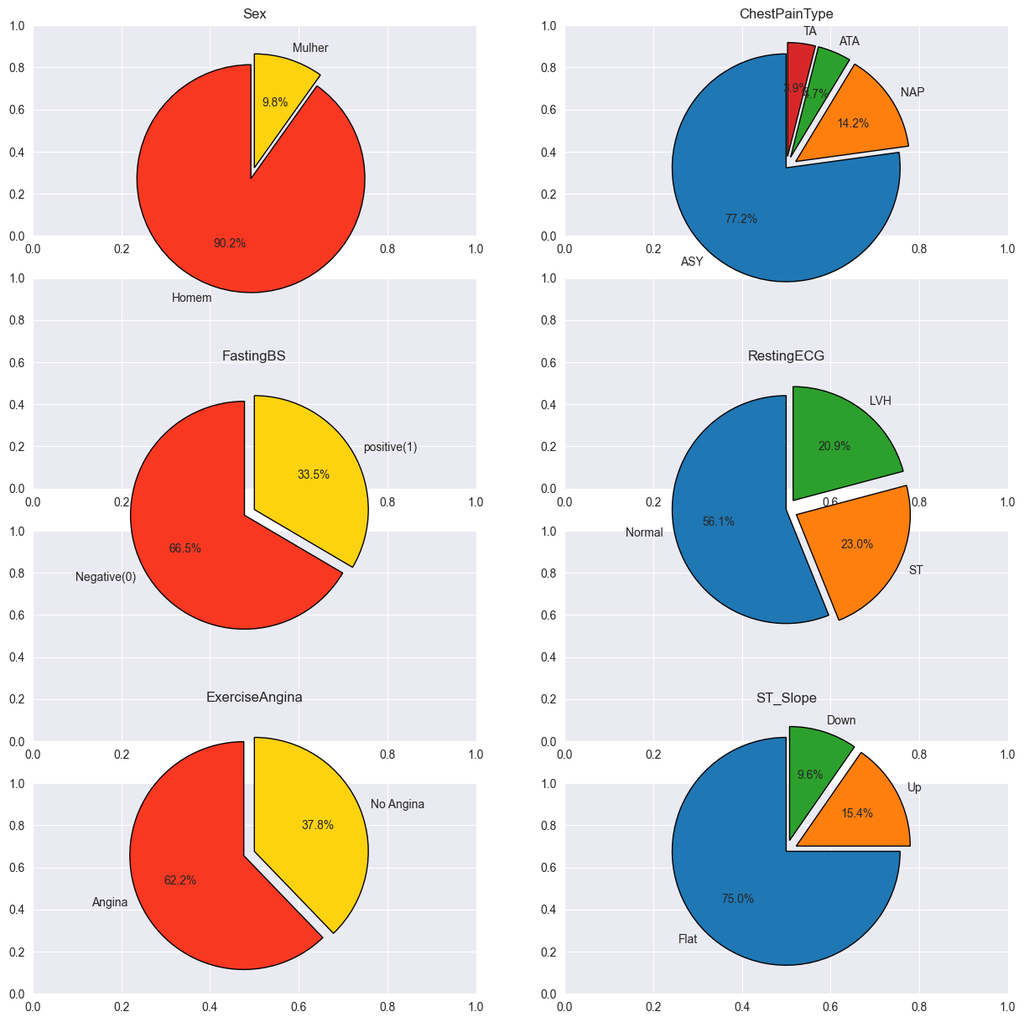

```python
sex = data[data['HeartDisease'] == 1]['Sex'].value_counts()
sex = [sex[0] / sum(sex) * 100, sex[1] / sum(sex) * 100]

cp = data[data['HeartDisease'] == 1]['ChestPainType'].value_counts()
cp = [cp[0] / sum(cp) * 100,cp[1] / sum(cp) * 100,cp[2] / sum(cp) * 100,cp[3] / sum(cp) * 100]

fbs = data[data['HeartDisease'] == 1]['FastingBS'].value_counts()
fbs = [fbs[0] / sum(fbs) * 100,fbs[1] / sum(fbs) * 100]

restecg = data[data['HeartDisease'] == 1]['RestingECG'].value_counts()
restecg = [restecg[0] / sum(restecg) * 100,restecg[1] / sum(restecg) * 100,restecg[2] / sum(restecg) * 100]

exang = data[data['HeartDisease'] == 1]['ExerciseAngina'].value_counts()
exang = [exang[0] / sum(exang) * 100,exang[1] / sum(exang) * 100]

slope = data[data['HeartDisease'] == 1]['ST_Slope'].value_counts()
slope = [slope[0] / sum(slope) * 100,slope[1] / sum(slope) * 100,slope[2] / sum(slope) * 100]
ax,fig = plt.subplots(nrows = 4,ncols = 2,figsize = (15,15))

plt.subplot(3,2,1)
plt.pie(sex,labels = ['Homem','Mulher'],autopct='%1.1f%%',startangle = 90,explode = (0.1,0),colors = colors,
        wedgeprops = {'edgecolor' : 'black','linewidth': 1,'antialiased' : True})
plt.title('Sex');

plt.subplot(3,2,2)
plt.pie(cp,labels = ['ASY', 'NAP', 'ATA', 'TA'],autopct='%1.1f%%',startangle = 90,explode = (0,0.1,0.1,0.1),
        wedgeprops = {'edgecolor' : 'black','linewidth': 1,'antialiased' : True})
plt.title('ChestPainType');

plt.subplot(3,2,3)
plt.pie(fbs,labels = ['Negative(0)','positive(1)'],autopct='%1.1f%%',startangle = 90,explode = (0.1,0),colors = colors,
        wedgeprops = {'edgecolor' : 'black','linewidth': 1,'antialiased' : True})
plt.title('FastingBS');

plt.subplot(3,2,4)
plt.pie(restecg,labels = ['Normal','ST','LVH'],autopct='%1.1f%%',startangle = 90,explode = (0,0.1,0.1),
        wedgeprops = {'edgecolor' : 'black','linewidth': 1,'antialiased' : True})
plt.title('RestingECG');

plt.subplot(3,2,5)
plt.pie(exang,labels = ['Angina','No Angina'],autopct='%1.1f%%',startangle = 90,explode = (0.1,0),colors = colors,
        wedgeprops = {'edgecolor' : 'black','linewidth': 1,'antialiased' : True})
plt.title('ExerciseAngina');

plt.subplot(3,2,6)
plt.pie(slope,labels = ['Flat','Up','Down'],autopct='%1.1f%%',startangle = 90,explode = (0,0.1,0.1),
        wedgeprops = {'edgecolor' : 'black','linewidth': 1,'antialiased' : True})
plt.title('ST_Slope');
```

- De todos os pacientes com HeartDisease, 90% são homens.
- Quando se trata de ChestPaintype, o tipo ASY detém a maioria com 77% que levam a doenças cardíacas.
- FastingBS apresenta altas chances de doenças cardíacas.
- Para RestingECG, o nível Normal é responsável por 56% das chances de doenças cardíacas do que os níveis de LVH e ST.
- A ExerciseAngina também aponta para doenças cardíacas.
- Quando se trata de leituras de ST_Slope, o nível Flat detém uma grande parte com 75% que pode ajudar a detectar problemas cardíacos subjacentes.

```python
X = data.drop(["HeartDisease"], axis=1)
Y = data["HeartDisease"]

# adicionando uma constante à variável X
X = add_constant(X)

# criando manequins
X = pd.get_dummies(X, drop_first=True, dtype = int)


# Dividindo dados em conjuntos de treinamento e teste
X_train, X_test, y_train, y_test = train_test_split(
    X, Y, test_size=0.30, random_state=1, stratify=Y
)
```

**Lembrando que, o argumento Stratify mantém a distribuição original de classes na variável de destino enquanto divide os dados em conjuntos de treinamento e teste.**

**Ajustando o modelo de regressão logística**

```python
# ajustando o modelo no conjunto de treinamento
logit = sm.Logit(y_train, X_train.astype(float))
lg = logit.fit()
```

```
Optimization terminated successfully.
         Current function value: 0.317529
         Iterations 7
```

```python
# imprimindo o resumo da regressão logística
print(lg.summary())
```

```
                           Logit Regression Results
==============================================================================
Dep. Variable:           HeartDisease   No. Observations:                  642
Model:                          Logit   Df Residuals:                      626
Method:                           MLE   Df Model:                           15
Date:                Mon, 05 Aug 2024   Pseudo R-squ.:                  0.5382
Time:                        23:11:21   Log-Likelihood:                -203.85
converged:                       True   LL-Null:                       -441.39
Covariance Type:            nonrobust   LLR p-value:                 1.048e-91
=====================================================================================
                        coef    std err          z      P>|z|      [0.025      0.975]
-------------------------------------------------------------------------------------
const                 0.2012      1.825      0.110      0.912      -3.375       3.777
Age                   0.0149      0.017      0.899      0.368      -0.018       0.047
RestingBP             0.0019      0.008      0.257      0.798      -0.013       0.017
Cholesterol        5.023e-05      0.002      0.021      0.983      -0.005       0.005
FastingBS             1.4763      0.334      4.424      0.000       0.822       2.130
MaxHR                -0.0173      0.006     -2.919      0.004      -0.029      -0.006
Oldpeak               0.4673      0.151      3.102      0.002       0.172       0.763
Sex_M                 1.5820      0.345      4.581      0.000       0.905       2.259
ChestPainType_ATA    -1.7487      0.390     -4.487      0.000      -2.513      -0.985
ChestPainType_NAP    -1.4414      0.317     -4.548      0.000      -2.063      -0.820
ChestPainType_TA     -0.8505      0.501     -1.696      0.090      -1.833       0.132
RestingECG_Normal    -0.1056      0.330     -0.320      0.749      -0.752       0.541
RestingECG_ST        -0.2133      0.416     -0.513      0.608      -1.028       0.601
ExerciseAngina_Y      0.7537      0.300      2.515      0.012       0.166       1.341
ST_Slope_Flat         1.1727      0.578      2.029      0.042       0.040       2.305
ST_Slope_Up          -1.3364      0.585     -2.283      0.022      -2.484      -0.189
=====================================================================================
```

**Verificando o desempenho do modelo**

```python
# prevendo no conjunto de treinamento
# o limite padrão é 0,5, se a probabilidade prevista for...
#... maior que 0,5 a observação será classificada como 1
pred_train = lg.predict(X_train) > 0.5
pred_train = np.round(pred_train)
```

```python
from sklearn.linear_model import LogisticRegression

logreg = LogisticRegression(random_state = 16,C=10,penalty= 'l2')

# ajuste o modelo com dados
logreg.fit(X_train, y_train,sample_weight=2)

y_pred = logreg.predict(X_test)
```

```python
logreg
```

```
LogisticRegression(C=10, random_state=16)
```

**Observando a matriz de confusão no conjunto de treinamento**

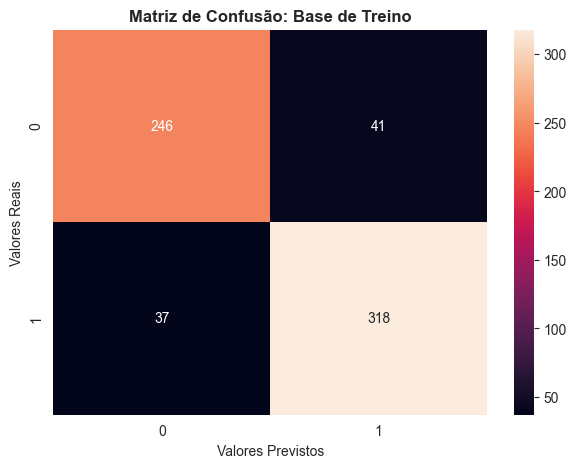

```python
cm = confusion_matrix(y_train, pred_train)
plt.figure(figsize=(7, 5))
sns.heatmap(cm, annot=True, fmt="g")
plt.title('Matriz de Confusão: Base de Treino', weight='bold')
plt.xlabel("Valores Previstos")
plt.ylabel("Valores Reais")
plt.show()
```

**Verificando o modelo de precisão**

```python
#print("Acurácia no conjunto de treinamento : ", accuracy_score(y_train, pred_train))
accuracy=accuracy_score(y_train, pred_train)
print("Acurácia no conjunto de treinamento:",(accuracy*100),'%')
```

```
Acurácia no conjunto de treinamento: 87.85046728971963 %
```

- Existem diferentes maneiras de detectar (ou testar) a multicolinearidade, uma delas é o Fator de Inflação de Variação.

**Verificando a multicolinearidade**

```python
# vamos verificar o VIF dos preditores
vif_series = pd.Series(
    [variance_inflation_factor(X_train.values, i) for i in range(X_train.shape[1])],
    index=X_train.columns,
    dtype=float,
)
print("VIF values: \n\n{}\n".format(vif_series))
```

```
VIF values:

const               213.824
Age                   1.419
RestingBP             1.099
Cholesterol           1.068
FastingBS             1.120
MaxHR                 1.530
Oldpeak               1.505
Sex_M                 1.106
ChestPainType_ATA     1.529
ChestPainType_NAP     1.266
ChestPainType_TA      1.131
RestingECG_Normal     1.756
RestingECG_ST         1.704
ExerciseAngina_Y      1.535
ST_Slope_Flat         5.010
ST_Slope_Up           5.904
dtype: float64
```

**ROC-AUC em conjunto de treinamento**

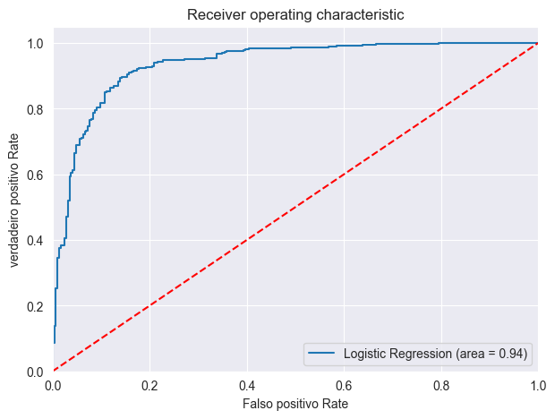

```python
logit_roc_auc_train = roc_auc_score(y_train, lg.predict(X_train))
fpr, tpr, thresholds = roc_curve(y_train, lg.predict(X_train))
plt.figure(figsize=(7, 5))
plt.plot(fpr, tpr, label="Logistic Regression (area = %0.2f)" % logit_roc_auc_train)
plt.plot([0, 1], [0, 1], "r--")
plt.xlim([0.0, 1.0])
plt.ylim([0.0, 1.05])
plt.xlabel("Falso positivo Rate")
plt.ylabel("verdadeiro positivo Rate")
plt.title("Receiver operating characteristic")
plt.legend(loc="lower right")
plt.show()
```

- O modelo está tendo um bom desempenho no conjunto de treinamento.

**Agora podemos usar o modelo para fazer previsões sobre os dados de teste.**

```python
pred_test = lg.predict(X_test) > 0.5
pred_test = np.round(pred_test)
```

```python
pred_test
```

```
239     True
740    False
592     True
573     True
199     True
       ...
646     True
596     True
351    False
750    False
744     True
Length: 276, dtype: bool
```

```python
#print("Accuracy on training set : ", accuracy_score(y_train, pred_train))
accuracy=accuracy_score(y_train, pred_train)
print("Acurácia no conjunto de treinamento:",(accuracy*100),'%')

#print("Accuracy on test set : ", accuracy_score(y_test, pred_test))
accuracy1=accuracy_score(y_test, pred_test)
print("Acurácia no conjunto de teste:",(accuracy1*100),'%')
```

```
Acurácia no conjunto de treinamento: 87.85046728971963 %
Acurácia no conjunto de teste: 82.97101449275362 %
```

- A regressão logística apresentou um desempenho generalizado nos conjuntos de treinamento e teste.

```python
from sklearn.metrics import classification_report
target_names = ['sem doença', 'com doença']
print(classification_report(y_test, y_pred, target_names=target_names))
```

```
              precision    recall  f1-score   support

  sem doença       0.85      0.77      0.81       123
  com doença       0.83      0.89      0.86       153

    accuracy                           0.84       276
   macro avg       0.84      0.83      0.83       276
weighted avg       0.84      0.84      0.84       276
```

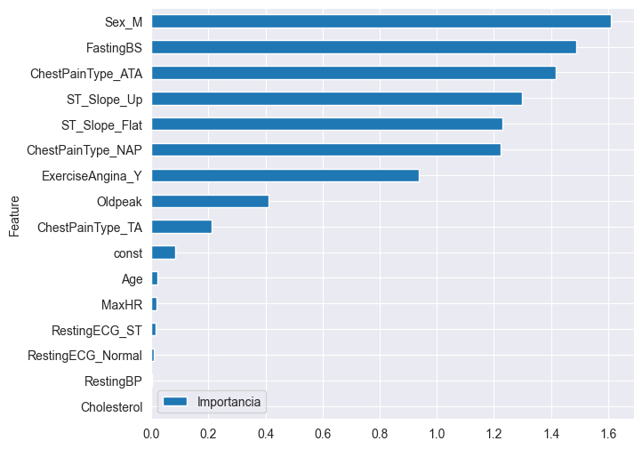

```python
coefficients = logreg.coef_[0]

feature_importance = pd.DataFrame({'Feature': X.columns, 'Importancia': np.abs(coefficients)})
feature_importance = feature_importance.sort_values('Importancia', ascending=True)
feature_importance.plot(x='Feature', y='Importancia', kind='barh', figsize=(7, 6))
```

# Outros modelos

**Testando todos os modélos supervisionados do tipo classificação**

```python
# importando biblioteca do Naive bayes
from sklearn.naive_bayes import GaussianNB

# importando biblioteca da arvore de decisão
from sklearn.tree import DecisionTreeClassifier

# importando biblioteca do KNN
from sklearn.neighbors import KNeighborsClassifier

# importando biblioteca do SVC
from sklearn.svm import SVC

models = {
    'Logistic Regression': LogisticRegression(),
    'Decision Tree': DecisionTreeClassifier(),
    'SVM': SVC(),
    'KNN': KNeighborsClassifier(),
    'Naive Bayes': GaussianNB()
}

for name, model in models.items():
    print(f"Treinamento {name}...")
    model.fit(X_train, y_train)
    y_pred = model.predict(X_test)
    accuracy = accuracy_score(y_test, y_pred)
    print(f"{name} Acurácia: {accuracy:.2f}")
    print(classification_report(y_test, y_pred))
```

```
Treinamento Logistic Regression...
Logistic Regression Acurácia: 0.83
              precision    recall  f1-score   support

           0       0.85      0.76      0.80       123
           1       0.82      0.89      0.86       153

    accuracy                           0.83       276
   macro avg       0.84      0.83      0.83       276
weighted avg       0.83      0.83      0.83       276

Treinamento Decision Tree...
Decision Tree Acurácia: 0.79
              precision    recall  f1-score   support

           0       0.78      0.75      0.76       123
           1       0.80      0.83      0.82       153

    accuracy                           0.79       276
   macro avg       0.79      0.79      0.79       276
weighted avg       0.79      0.79      0.79       276

Treinamento SVM...
SVM Acurácia: 0.65
              precision    recall  f1-score   support

           0       0.62      0.54      0.58       123
           1       0.66      0.74      0.70       153

    accuracy                           0.65       276
   macro avg       0.64      0.64      0.64       276
weighted avg       0.65      0.65      0.64       276

Treinamento KNN...
KNN Acurácia: 0.68
              precision    recall  f1-score   support

           0       0.65      0.59      0.62       123
           1       0.70      0.75      0.72       153

    accuracy                           0.68       276
   macro avg       0.67      0.67      0.67       276
weighted avg       0.68      0.68      0.68       276

Treinamento Naive Bayes...
Naive Bayes Acurácia: 0.84
              precision    recall  f1-score   support

           0       0.86      0.77      0.81       123
           1       0.83      0.90      0.86       153

    accuracy                           0.84       276
   macro avg       0.84      0.83      0.84       276
weighted avg       0.84      0.84      0.84       276
```

**Acurácia do modelo**

```python
for name, model in models.items():
    model.fit(X_train, y_train)
    y_pred = model.predict(X_test)
    accuracy = accuracy_score(y_test, y_pred)
    print(f"{name} Accuracy: {accuracy:.2f}")
```

```
Logistic Regression Accuracy: 0.83
Decision Tree Accuracy: 0.79
SVM Accuracy: 0.65
KNN Accuracy: 0.68
Naive Bayes Accuracy: 0.84
```

**Comparação entre os modelos**

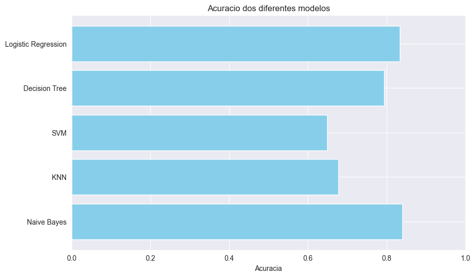

```python
# Dicionário para armazenar as acuracias
accuracies = {}

for name, model in models.items():
    model.fit(X_train, y_train)
    y_pred = model.predict(X_test)
    accuracy = accuracy_score(y_test, y_pred)
    accuracies[name] = accuracy

# Create a bar plot for accuracies
plt.figure(figsize=(10, 6))
plt.barh(list(accuracies.keys()), list(accuracies.values()), color='skyblue')
plt.xlabel('Acuracia')
plt.title('Acuracia dos diferentes modelos')
plt.xlim(0, 1)
plt.gca().invert_yaxis()
plt.show()
```

- Como podemos observar, o Naive Bayes apresentou melhor acuracia em relação aos demais, sendo que o mesmo esta muito proximo do resultado da regressão logistica.

## Conclusões sobre o trabalho de regressão Logística

- O modelo foi treinado com sucesso. A Acurácia nos diz que o nosso modelo consegue acertar em torno de 83% das predições.